# Kapitel 4, ARM

ses

6/15/2021

# 1 Quelle

https://sebastiansauer.github.io/2021-sose/QuantMeth1/Syntax/2021-06-15.html

# 2 Pakete laden

```r
library(tidyverse)
library(arm)  # nicht wirklich wichtig, nur für Funktion "display"
```

# 3 Lineare Transformationen 1: Linearen Einfluss auf Regressionsgewichte, kein Einfluss auf $R^2$

## 3.1 Daten laden: `earn`

Vgl. S. 53 in ARM, Kap. 4:

```r
earn <- read_csv("https://raw.githubusercontent.com/sebastiansauer/2021-sose/master/data/ARM/heights.csv")
glimpse(earn)
```

```
## Rows: 2,029
## Columns: 9
## $ earn    <dbl> NA, NA, 50000, 60000, 30000, NA, 50000, NA, 51000, 9000, 29000…
## $ height1 <dbl> 5, 5, 6, 5, 5, 5, 5, 5, 5, 5, 5, 6, 6, 6, 6, 5, 5, 5, 5, 5, 5,…
## $ height2 <dbl> 6, 4, 2, 6, 4, 5, 3, 8, 3, 4, 2, 1, 0, 0, 0, 10, 3, 8, 8, 11, …
## $ sex     <dbl> 2, 1, 1, 2, 2, 2, 2, 2, 2, 2, 2, 1, 1, 1, 1, 1, 2, 1, 1, 1, 2,…
## $ race    <dbl> 1, 2, 1, 1, 1, 1, 3, 2, 1, 1, 1, 1, 1, 1, 1, 1, 1, 1, 1, 1, 1,…
## $ hisp    <dbl> 2, 2, 2, 2, 2, 2, 2, 2, 2, 2, 2, 2, 1, 2, 2, 2, 2, 2, 2, 2, 2,…
## $ ed      <dbl> 12, 12, 16, 16, 16, 17, 16, 18, 17, 15, 12, 17, 15, 99, 12, 16…
## $ yearbn  <dbl> 53, 50, 45, 32, 61, 33, 99, 36, 51, 64, 41, 44, 69, 37, 64, 25…
## $ height  <dbl> 66, 64, 74, 66, 64, 65, 63, 68, 63, 64, 62, 73, 72, 72, 72, 70…
```

Wir ändern die Skalierung des Prädiktors (Varianz, sd). Was hat das für die Regr.gewichte und für $R^2$?

## 3.2 lm0

```r
lm0 <- lm(earn ~ height,
          data = earn)
display(lm0)
```

```
## lm(formula = earn ~ height, data = earn)
##             coef.est  coef.se
## (Intercept) -84078.32   8901.10
## height        1563.14    133.45
## ---
## n = 1379, k = 2
## residual sd = 18853.92, R-Squared = 0.09
```

```r
earn <-
  earn %>%
  mutate(height_cm = height / 2.54,
         height_mm = height_cm / 10,
         height_m = height_cm * 100)
```

```r
lm0a <- lm(earn ~ height_cm,
          data = earn)
display(lm0a)
```

```
## lm(formula = earn ~ height_cm, data = earn)
##             coef.est  coef.se
## (Intercept) -84078.32   8901.10
## height_cm     3970.37    338.96
## ---
## n = 1379, k = 2
## residual sd = 18853.92, R-Squared = 0.09
```

```r
lm0b <- lm(earn ~ height_mm,
          data = earn)
display(lm0b)
```

```
## lm(formula = earn ~ height_mm, data = earn)
##             coef.est  coef.se
## (Intercept) -84078.32   8901.10
## height_mm    39703.70   3389.57
## ---
## n = 1379, k = 2
## residual sd = 18853.92, R-Squared = 0.09
```

```r
lm0c <- lm(earn ~ height_m,
          data = earn)
display(lm0c)
```

```
## lm(formula = earn ~ height_m, data = earn)
##             coef.est  coef.se
## (Intercept) -84078.32   8901.10
## height_m        39.70      3.39
## ---
## n = 1379, k = 2
## residual sd = 18853.92, R-Squared = 0.09
```

# 4 Lineare Transformationen 2: Zentrieren und z-Transformationen

## 4.1 Daten laden: `kidsiq`

S. 55., 4.2 ARM:

```r
kidsiq <- read_csv("https://raw.githubusercontent.com/sebastiansauer/2021-sose/master/data/ARM/kidsiq.csv")
```

## 4.2 lm1: Interaktionseffekt

```r
lm1 <- lm(kid_score ~ mom_hs + mom_iq + mom_hs:mom_iq,
          data = kidsiq)
display(lm1)
```

```
## lm(formula = kid_score ~ mom_hs + mom_iq + mom_hs:mom_iq, data = kidsiq)
##               coef.est coef.se
## (Intercept)   -11.48    13.76
## mom_hs         51.27    15.34
## mom_iq          0.97     0.15
## mom_hs:mom_iq  -0.48     0.16
## ---
## n = 434, k = 4
## residual sd = 17.97, R-Squared = 0.23
```

Interpretation!

## 4.3 lm2: Zentrieren

```r
kidsiq <-
  kidsiq %>%
  mutate(mom_hs_c = mom_hs - mean(mom_hs),
         mom_iq_c = mom_iq - mean(mom_iq))  # centered
```

Effekte des Zentrierens:

```r
kidsiq %>%
  summarise(mom_iq_avg = mean(mom_iq),
            mom_iq_c_avg = mean(mom_iq_c),
            mom_iq_sd = sd(mom_iq),
            mom_iq_c_sd = sd(mom_iq_c))
```

```
## # A tibble: 1 x 4
##   mom_iq_avg mom_iq_c_avg mom_iq_sd mom_iq_c_sd
##        <dbl>        <dbl>     <dbl>       <dbl>
## 1        100     6.95e-16        15          15
```

```r
kidsiq %>%
  summarise(mom_hs_avg = mean(mom_hs),
            mom_hs_c_avg = mean(mom_hs_c),
            mom_hs_sd = sd(mom_hs),
            mom_hs_c_sd = sd(mom_hs_c))
```

```
## # A tibble: 1 x 4
##   mom_hs_avg mom_hs_c_avg mom_hs_sd mom_hs_c_sd
##        <dbl>        <dbl>     <dbl>       <dbl>
## 1      0.786     1.59e-17     0.411       0.411
```

```r
kidsiq %>%
  count(mom_hs_c)
```

```
## # A tibble: 2 x 2
##   mom_hs_c     n
##      <dbl> <int>
## 1   -0.786    93
## 2    0.214   341
```

### 4.3.1 Mit Zentrieren des binären Prädiktors

```r
lm2 <- lm(kid_score ~ mom_hs_c + mom_iq_c + mom_hs_c:mom_iq_c,
          data = kidsiq)
display(lm2)
```

```
## lm(formula = kid_score ~ mom_hs_c + mom_iq_c + mom_hs_c:mom_iq_c,
##     data = kidsiq)
##                   coef.est coef.se
## (Intercept)       87.64     0.91
## mom_hs_c           2.84     2.43
## mom_iq_c           0.59     0.06
## mom_hs_c:mom_iq_c -0.48     0.16
## ---
## n = 434, k = 4
## residual sd = 17.97, R-Squared = 0.23
```

### 4.3.2 Ohne Zentrieren des binären Prädiktors

```r
lm2a <- lm(kid_score ~ mom_hs + mom_iq_c + mom_hs:mom_iq_c,
          data = kidsiq)
display(lm2a)
```

```
## lm(formula = kid_score ~ mom_hs + mom_iq_c + mom_hs:mom_iq_c,
##     data = kidsiq)
##                 coef.est coef.se
## (Intercept)     85.41     2.22
## mom_hs           2.84     2.43
## mom_iq_c         0.97     0.15
## mom_hs:mom_iq_c -0.48     0.16
## ---
## n = 434, k = 4
## residual sd = 17.97, R-Squared = 0.23
```

Interpretation:

- Achsenabschnitt: Ohne Highschool-Abschluss und mit mitlerer Intelligenz ist laut Modell ein Testwert (Y-Wert) von im Schnitt ca. 85 Punkten zu erwarten.
- `mom_hs`: Der Unterschied im Testwert, wenn man Mütter mit bzw. ohne HS-Abschluss und mittlerer Intelligenz vergleicht, liegt bei knapp 3 Punkte.
- `mom_iq_c`: Der Unterschied im Testwert, wenn man Mütter mit einem Punkt Unterschied im IQ-Wert vergleicht (und bei Müttern *ohne* HS-Abschluss), liegt bei 0.97 Punkten.
- `mom_hs:mom_iq_c`: Der Unterschied im Testwert im Vergleich zu `mom_iq_c`, wenn man Mütter mit einem Punkt Unterschied im IQ-Wert vergleich (und bei Müttern *mit* HS-Abschluss), liegt bei 0.97 - 0.48 = 0.49 Punkten.

### 4.3.3 Zentriert vs. nicht-zentrierte Modelle mit einem Prädiktor

Hat man nur einen Prädiktor, so ändert das Zentrieren das Regressionsgewicht ($\beta$) nicht:

```r
lm2b <- lm(kid_score ~ mom_iq, data = kidsiq)
display(lm2b)
```

```
## lm(formula = kid_score ~ mom_iq, data = kidsiq)
##             coef.est coef.se
## (Intercept) 25.80     5.92
## mom_iq       0.61     0.06
## ---
## n = 434, k = 2
## residual sd = 18.27, R-Squared = 0.20
```

```r
lm2c <- lm(kid_score ~ mom_iq_c, data = kidsiq)
display(lm2c)
```

```
## lm(formula = kid_score ~ mom_iq_c, data = kidsiq)
##             coef.est coef.se
## (Intercept) 86.80     0.88
## mom_iq_c     0.61     0.06
## ---
## n = 434, k = 2
## residual sd = 18.27, R-Squared = 0.20
```

Im Beispiel oben hat sich durch das Zentrieren der Wert der Regressionsgewichte der Prädiktoren `mom_iq_c` und `mom_hs_c` geändert. Das liegt daran, dass mehr als ein Prädiktor (inkl. Interaktionseffekt) im Modell vorhanden ist.

## 4.4 Interaktionseffekt visualisieren

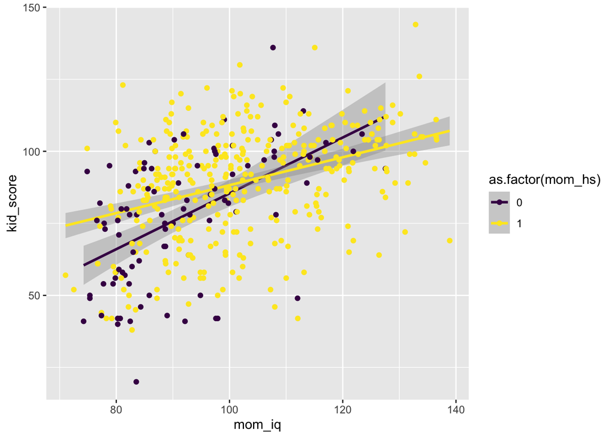

```r
kidsiq %>%
  ggplot(aes(x = mom_iq, y = kid_score, color = as.factor(mom_hs))) +
  geom_smooth(method = "lm") +
  geom_point() +
   scale_color_viridis_d()
```

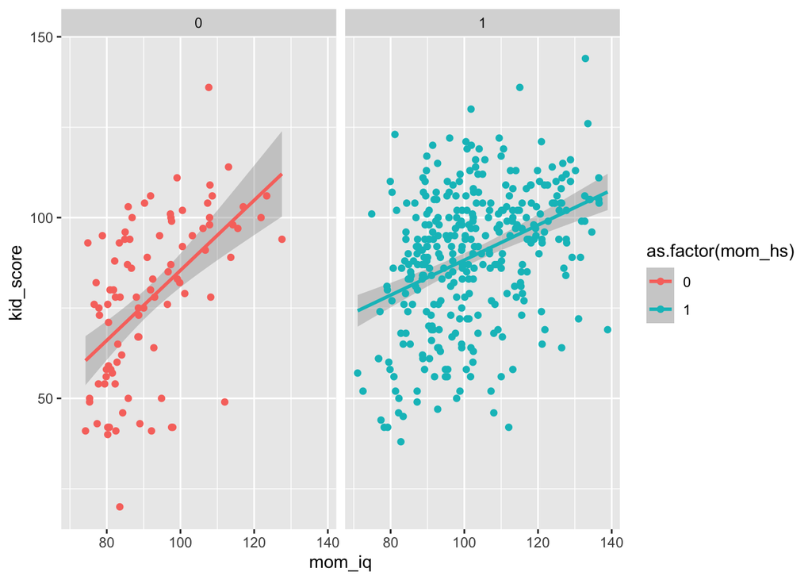

```r
kidsiq %>%
  ggplot(aes(x = mom_iq, y = kid_score, color = as.factor(mom_hs))) +
  facet_wrap(~ mom_hs) +
  geom_smooth(method = "lm") +
  geom_point()
```

## 4.5 lm3: z-Transformation

```r
kidsiq <-
  kidsiq %>%
  mutate(mom_iq_z = (mom_iq - mean(mom_iq)) / sd(mom_iq),
         mom_hs_z = (mom_hs - mean(mom_hs)) / sd(mom_hs))
```

```r
kidsiq %>%
  count(mom_hs_z)
```

```
## # A tibble: 2 x 2
##   mom_hs_z     n
##      <dbl> <int>
## 1   -1.91     93
## 2    0.522   341
```

### 4.5.1 Ohne Transformation von `mom_hs`, sondern nur `mom_iq`

```r
lm3 <- lm(kid_score ~ mom_hs + mom_iq_z + mom_hs:mom_iq_z,
          data = kidsiq)

display(lm3)
```

```
## lm(formula = kid_score ~ mom_hs + mom_iq_z + mom_hs:mom_iq_z,
##     data = kidsiq)
##                 coef.est coef.se
## (Intercept)     85.41     2.22
## mom_hs           2.84     2.43
## mom_iq_z        14.53     2.23
## mom_hs:mom_iq_z -7.26     2.43
## ---
## n = 434, k = 4
## residual sd = 17.97, R-Squared = 0.23
```

Interpretation:

- Achsenabschnitt: *Ohne* Highschool-Abschluss und mit mitlerer Intelligenz ist laut Modell ein Testwert (Y-Wert) von im Schnitt ca. 85 Punkten zu erwarten.
- `mom_hs`: Der Unterschied im Testwert, wenn man Mütter mit bzw. ohne HS-Abschluss und mittlerer Intelligenz vergleicht, liegt bei knapp 3 Punkte.
- `mom_iq_z`: Der Unterschied im Testwert, wenn man Mütter pro zusätzlicher Stufe von `mom_iq_z` (d.h. eine SD-Einheit höher) vergleicht (und bei Müttern *ohne* HS-Abschluss), liegt bei ca. 15 Punkten.
- `mom_hs:mom_iq_c`: Der Unterschied im Testwert im Vergleich zu `mom_iq_c`, wenn man Mütter pro zusätzlicher Stufe von `mom_iq_c` (d.h. eine SD-Einheit höher) vergleicht (und bei Müttern *mit* HS-Abschluss), liegt bei ca. 15 - 7 ) 8 Punkten.

### 4.5.2 Mit z-Transformation von `mom_hs`

```r
kidsiq %>%
  summarise(mom_hs_sd = sd(mom_hs),
            mom_hs_avg = mean(mom_hs))
```

```
## # A tibble: 1 x 2
##   mom_hs_sd mom_hs_avg
##       <dbl>      <dbl>
## 1     0.411      0.786
```

```r
lm3a <- lm(kid_score ~ mom_hs_z + mom_iq_z + mom_hs_z:mom_iq_z,
          data = kidsiq)

display(lm3a)
```

```
## lm(formula = kid_score ~ mom_hs_z + mom_iq_z + mom_hs_z:mom_iq_z,
##     data = kidsiq)
##                   coef.est coef.se
## (Intercept)       87.64     0.91
## mom_hs_z           1.17     1.00
## mom_iq_z           8.83     0.91
## mom_hs_z:mom_iq_z -2.98     1.00
## ---
## n = 434, k = 4
## residual sd = 17.97, R-Squared = 0.23
```

Interpretation:

- Achsenabschnitt: *Ohne* Highschool-Abschluss und mit mitlerer Intelligenz ist laut Modell ein Testwert (Y-Wert) von im Schnitt ca. 87 Punkten zu erwarten.
- `mom_hs_z`: Der Unterschied im Testwert, wenn man der Bildungswert um eine SD-Einheit steigt. Dieser Wert ist hier kaum zu interpretieren.
- `mom_iq_z`: Der Unterschied im Testwert, wenn man Mütter pro zusätzlicher Stufe von `mom_iq_z` (d.h. eine SD-Einheit höher) vergleicht (und bei Müttern mit *mittlerem* HS-Abschluss), liegt bei ca. 9 Punkten.
- `mom_hs_z:mom_iq_z`: Der Unterschied im Testwert im Vergleich zu `mom_iq_z`, wenn man Mütter pro zusätzlicher Stufe von `mom_iq_z` (d.h. eine SD-Einheit höher) vergleicht und wenn man Frauen mit einem Wert in `mom_hs_z` von 1 betrachtet. Da ein Wert von 1in `mom_hs_z` keine Entsprechung in den Daten hat, ist dieser Koeffizient kaum zu interpretieren.

### 4.5.3 Binäre Prädiktoren nicht zentrieren/z-transformieren

Insgesamt scheint eine Standardisierung der binären Prädiktoren nur eingeschränkt nützlich zu sein. Ich empfehle, binäre Prädiktoren nicht zu zentieren oder z-transfomieren, sondern sie zu belassen, wie sie sind oder eine z2-Transformation anzuwenden.

### 4.5.4 z2-Transformation

```r
kidsiq <-
  kidsiq %>%
  mutate(mom_iq_z2 = (mom_iq - mean(mom_iq)) / (2*sd(mom_iq)),
         mom_hs_z2 = (mom_hs - mean(mom_hs)) / (2*sd(mom_hs)))
```

```r
kidsiq %>%
  count(mom_hs_z)
```

```
## # A tibble: 2 x 2
##   mom_hs_z     n
##      <dbl> <int>
## 1   -1.91     93
## 2    0.522   341
```

```r
kidsiq %>%
  count(mom_hs_z2)
```

```
## # A tibble: 2 x 2
##   mom_hs_z2     n
##       <dbl> <int>
## 1    -0.956    93
## 2     0.261   341
```

```r
lm3b <- lm(kid_score ~ mom_hs_z2 + mom_iq_z2 + mom_hs_z2:mom_iq_z2,
          data = kidsiq)

display(lm3b)
```

```
## lm(formula = kid_score ~ mom_hs_z2 + mom_iq_z2 + mom_hs_z2:mom_iq_z2,
##     data = kidsiq)
##                     coef.est coef.se
## (Intercept)          87.64     0.91
## mom_hs_z2             2.33     1.99
## mom_iq_z2            17.65     1.82
## mom_hs_z2:mom_iq_z2 -11.94     4.00
## ---
## n = 434, k = 4
## residual sd = 17.97, R-Squared = 0.23
```

Interpretation:

- Achsenabschnitt: Ein Kind mit mittlerer Ausprägung in den Prädiktorwerten hat laut Modell im Schnitt einen Testwert von ca. 88 Punkten.
- `mom_hs_z2`: Vergleicht man HS-Abschluss ja vs. nein und betrachtet nur Mütter mit mittlerer Intelligenz, so beträgt der erwartete Unterschied im Testwert ca. 2 Punkte.
- `mom_iq_z2`: Vergleicht man Mütter, deren IQ-Werte sich um 2 SD-Einheiten unterscheiden und die über einen mittleren Wert in HS-Abschluss verfügen, so findet man einen Unterschied von ca. 18 Punkten in den Testwerten.
- `mom_hs_z2:mom_iq_z2`: Der Unterschied im Effekt des IQ auf den Testwert zwischen Frauen ohne bzw. mit HS-Abschluss auf die Testwerte liegt bei ca. -12 Punkte, d.h. bei Frauen mit Abschluss ist der Effekt des IQ auf die Testwerte geringer.

Der Vorteil der z2-Transformation ist, dass die Koeffizienten der binären Variablen den Unterschied zwischen 0 und 1 widerspiegeln. Bei der z-Transformation spiegeln Sie den *halben* Unterschied zwischen dem 0-Wert bzw. 1-Wert wider.

## 4.6 Binäre Prädiktoren besser nicht standardisieren

Insgesamt ist die ganze Angelegenheit der Interpretation von standardisierten Prädiktoren nicht einfach. Ich empfehle daher, binäre Prädiktoren nicht zu standardisieren.

# 5 Modelle mit `log(y)`

4.4 in ARM

$y=ab$, $y ~ x*y$ –> log(Y)

*Multiplikative Zusammenhänge!*

S. 59

log(y) = b0 + b1*x1 + … | eponenziere

y = e^(b0 + b1*x1 + … )

y = e^b0 * e^b1x1 * …

## 5.1 lm4: earn_log

```r
earn <-
  earn %>%
  mutate(earn_log = log(earn))
```

Zur Basis e.

*Achtung: log nur für x > 0!*

```r
lm4 <- lm(earn_log ~ height,
          data = earn %>% filter(earn > 0))
display(lm4)
```

```
## lm(formula = earn_log ~ height, data = earn %>% filter(earn >
##     0))
##             coef.est coef.se
## (Intercept) 5.78     0.45
## height      0.06     0.01
## ---
## n = 1192, k = 2
## residual sd = 0.89, R-Squared = 0.06
```

Was bedeutet der Wert 0.06?

–> Steigt X (height) um 1, so steigt im Modell Y um 0.06 log-Punkte: `earn` steigt um *6%*!

Zum Vergleich: additives Modell:

```r
lm4a <- lm(earn ~ height,
          data = earn %>% filter(earn > 0))
display(lm4a)
```

```
## lm(formula = earn ~ height, data = earn %>% filter(earn > 0))
##             coef.est  coef.se
## (Intercept) -61316.28   9525.18
## height        1262.33    142.11
## ---
## n = 1192, k = 2
## residual sd = 18865.08, R-Squared = 0.06
```

Hier leider R^2 beim multiplikativen Modell (log-Modell) nicht besser, entgegen der Erwartung.

## 5.2 lm5: earn_log mit zwei Prädiktoren

```r
earn %>%
  count(sex)
```

```
## # A tibble: 2 x 2
##     sex     n
##   <dbl> <int>
## 1     1   748
## 2     2  1281
```

Leider wissen wir nicht, ob Frauen mit 1 oder mit 2 codiert sind. Gehen wir davon aus, dass Männer mit 1 kodiert sind (vgl. Buch ARM, S. 61).

```r
earn <-
  earn %>%
  mutate(male = case_when(
    sex == 2 ~ 0,  # Frau
    sex == 1 ~ 1))  # Mann
```

```r
lm5 <- lm(earn_log ~ height + male,
          data = earn %>% filter(earn > 0))
display(lm5)
```

```
## lm(formula = earn_log ~ height + male, data = earn %>% filter(earn >
##     0))
##             coef.est coef.se
## (Intercept) 8.15     0.60
## height      0.02     0.01
## male        0.42     0.07
## ---
## n = 1192, k = 3
## residual sd = 0.88, R-Squared = 0.09
```

## 5.3 lm6: Mit z-Transformation und Interaktion

```r
earn <-
  earn %>%
  mutate(height_z = scale(height))
```

```r
lm6 <- lm(earn_log ~ height_z + male + height_z:male,
          data = earn %>% filter(earn > 0))
display(lm6)
```

```
## lm(formula = earn_log ~ height_z + male + height_z:male, data = earn %>%
##     filter(earn > 0))
##               coef.est coef.se
## (Intercept)   9.52     0.04
## height_z      0.06     0.05
## male          0.42     0.07
## height_z:male 0.03     0.07
## ---
## n = 1192, k = 4
## residual sd = 0.88, R-Squared = 0.09
```

Delogarithimieren zur Interpretation der Koeffizienten

```r
exp(9.52)
```

```
## [1] 13629.61
```

```r
exp(0.06)
```

```
## [1] 1.061837
```

```r
exp(0.42)
```

```
## [1] 1.521962
```

Die Reihenfolge der Prädiktoren spielt *keine* Rolle:

```r
lm6a <- lm(earn_log ~ height_z:male + male + height_z ,
          data = earn %>% filter(earn > 0))
display(lm6)
```

```
## lm(formula = earn_log ~ height_z + male + height_z:male, data = earn %>%
##     filter(earn > 0))
##               coef.est coef.se
## (Intercept)   9.52     0.04
## height_z      0.06     0.05
## male          0.42     0.07
## height_z:male 0.03     0.07
## ---
## n = 1192, k = 4
## residual sd = 0.88, R-Squared = 0.09
```

# 6 LogY-LogX-Modelle

```r
earn <-
  earn %>%
  mutate(height_log = log(height))
```

```r
lm7 <- lm(earn_log ~ height_log + male,
          data = earn %>% filter(earn > 0))
display(lm7)
```

```
## lm(formula = earn_log ~ height_log + male, data = earn %>% filter(earn >
##     0))
##             coef.est coef.se
## (Intercept) 3.62     2.60
## height_log  1.41     0.62
## male        0.42     0.07
## ---
## n = 1192, k = 3
## residual sd = 0.88, R-Squared = 0.09
```

# 7 Weitere Transformationen

## 7.1 Diskretisierung metrischer Prädiktoren

```r
lm7 <- lm(kid_score ~ as.factor(mom_work),
          data = kidsiq)
display(lm7)
```

```
## lm(formula = kid_score ~ as.factor(mom_work), data = kidsiq)
##                      coef.est coef.se
## (Intercept)          82.00     2.31
## as.factor(mom_work)2  3.85     3.09
## as.factor(mom_work)3 11.50     3.55
## as.factor(mom_work)4  5.21     2.70
## ---
## n = 434, k = 4
## residual sd = 20.23, R-Squared = 0.02
```

# 8 “Buschbeispiel” - `mesquite`

## 8.1 Daten laden: `mesquite`

```r
mesquite <- read_csv("https://raw.githubusercontent.com/sebastiansauer/2021-sose/master/data/ARM/mesquite.csv")
glimpse(mesquite)
```

```
## Rows: 46
## Columns: 8
## $ Obs    <dbl> 1, 2, 3, 4, 5, 6, 7, 8, 9, 10, 11, 12, 13, 14, 15, 16, 17, 18, …
## $ Group  <chr> "MCD", "MCD", "MCD", "MCD", "MCD", "MCD", "MCD", "MCD", "MCD", …
## $ Diam1  <dbl> 1.8, 1.7, 2.8, 1.3, 3.3, 1.4, 1.5, 3.9, 1.8, 2.1, 0.8, 1.3, 1.2…
## $ Diam2  <dbl> 1.15, 1.35, 2.55, 0.85, 1.90, 1.40, 0.50, 2.30, 1.35, 1.60, 0.6…
## $ TotHt  <dbl> 1.30, 1.35, 2.16, 1.80, 1.55, 1.20, 1.00, 1.70, 0.80, 1.20, 0.9…
## $ CanHt  <dbl> 1.00, 1.33, 0.60, 1.20, 1.05, 1.00, 0.90, 1.30, 0.60, 0.80, 0.6…
## $ Dens   <dbl> 1, 1, 1, 1, 1, 1, 1, 2, 1, 1, 1, 1, 1, 1, 1, 1, 1, 1, 1, 1, 1, …
## $ LeafWt <dbl> 401.3, 513.7, 1179.2, 308.0, 855.2, 268.7, 155.5, 1253.2, 328.0…
```

## 8.2 Lineares Modell mit allen Prädiktoren

Vgl. S. 70 in ARM; die Daten passen nicht ganz zum Buch. Die Werte weichen etwas zum Buch ab.

```r
lm7 <- lm(LeafWt ~ ., data = mesquite)
display(lm7)
```

```
## lm(formula = LeafWt ~ ., data = mesquite)
##             coef.est coef.se
## (Intercept) -970.66   312.68
## Obs           -2.88     6.10
## GroupMCD     292.19   181.51
## Diam1        189.17   113.91
## Diam2        372.31   125.65
## TotHt       -110.57   188.39
## CanHt        358.34   212.04
## Dens         129.16    34.98
## ---
## n = 46, k = 8
## residual sd = 271.68, R-Squared = 0.85
```

## 8.3 Multiplikatives Modell

```r
lm8 <- lm(log(LeafWt) ~ log(Diam1) + log(Diam2) + log(TotHt) + log (CanHt) + log(Dens) + Group,
          data = mesquite)

display(lm8)
```

```
## lm(formula = log(LeafWt) ~ log(Diam1) + log(Diam2) + log(TotHt) +
##     log(CanHt) + log(Dens) + Group, data = mesquite)
##             coef.est coef.se
## (Intercept) 4.77     0.16
## log(Diam1)  0.39     0.28
## log(Diam2)  1.15     0.21
## log(TotHt)  0.39     0.31
## log(CanHt)  0.37     0.28
## log(Dens)   0.11     0.12
## GroupMCD    0.58     0.13
## ---
## n = 46, k = 7
## residual sd = 0.33, R-Squared = 0.89
```

# 9 Zusammenfassung

Zahlenbeispiel zu IQ

- MW = 100
- sd = 15
- Messwert (X) = 115

## 9.1 Zentrieren (c-Transformation)

Wir verschieben wir den Nullpunkt auf den MW.

Nutzen: Achsenabschnitt (und Interaktionseffekte) werden damit interpretierbar(er).

Interpreation von Achsenabscnitt: Y-Wert, wenn X beim MW (also mittlerer X-Wert)

Rechnen: x_c = X - mean(X)

Z.B. X=115, mw_X = 100 -> X_c = 115 - 100 = 15

Der zentrierte Wert X_c zeigt also den *Abstand zum Mittelwert.*

# 10 Z-Transformieren

Z-transformierte Werte sind immer auch zentriert.

Nutzen: Regressiongewichte werden vergleichbar, da gleiche Skalierung.

Rechnen: x_z = z_c / sd(X)

z.B. X=115, mw_X = 100, sd_X = 15

x_z = x_z / 15 = 15 / 15 = 1